# Linear Regression with Python

### What is Linear Regression ?

#### 1. Supervised machine learning algrorithm for performing regression task.

#### 2. Linear Regression approach is based on assumption that there is a linear relationship between dependent variable (Y) and independent variables (X s).

### Simple Linear Regression

#### Simple linear regression focuses on determining relationship between one independent (explanatory variable) variable and one dependent variable.

##### Dataset

```python
import numpy as np
import pandas as pd
import Toggle
import random
pd.set_option('display.max_rows', 6)
df = pd.read_csv('dataSet.csv')
df.rename(columns = {'BMXWAIST':'X','BMXBMI':'Y'}, inplace = True)
dfx = df[['X','Y']].copy(deep=True)
indLst = list(np.arange(len(dfx)))
random.seed(2)
selLst = random.sample(indLst,30)
dfxs = dfx.iloc[selLst].reset_index(drop=True)
#print(dfxs.X.values)
#print(dfxs.Y.values)
#df.rename(columns = {'X4 number of convenience stores':'X','Y house price of unit area':'Y'}, inplace = True)
print('X : Waist Circumference in cm')
print('Y : BMI')
print('N : Number of samples')
#print('Total Samples : ',len(df))
display(dfxs)
#display(df)
Toggle.hide_toggle()
```

```
X : Waist Circumference in cm
Y : BMI
N : Number of samples
```

|  | X | Y |
| --- | --- | --- |
| 0 | 96.4 | 30.8 |
| 1 | 111.4 | 31.0 |
| 2 | 116.8 | 36.7 |
| ... | ... | ... |
| 27 | 130.2 | 38.8 |
| 28 | 114.3 | 34.2 |
| 29 | 100.2 | 30.7 |

30 rows × 2 columns

S/H

##### Scatter Plot

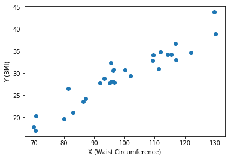

S/H

```python
import matplotlib.pyplot as plt
plt.scatter(dfxs.X,dfxs.Y)
plt.xlabel("X (Waist Circumference)")
plt.ylabel("Y (BMI)")
plt.show()
Toggle.hide_toggle()
```

#### Linear Regression Model

$\hat{y} = mx + c$  
$m$ = Slope  
$c$ = Intercept  
$\hat{y}$ = Predicted value of y

#### The aim is to minimize cost function $J(m,c)$

$J(m,c) = \frac{1}{2N} \sum_{i=1}^{N} (\hat{y}_i-y_i)^2$  
$J(m,c) = \frac{1}{2N} \sum_{i=1}^{N} (mx_i+c-y_i)^2$

#### Using partial derivative $m$ and $c$ can be calculated

#### Basically, we are minimizing Mean Square Error (MSE)

$MSE = \frac{1}{N} \sum_{i=1}^{N} (\hat{y}_i-y_i)^2$

### Using Scikit-Learn (sklearn) to fit Linear Regression Model

```
m =  0.35688781271171566
c =  -6.0432710210021945
```

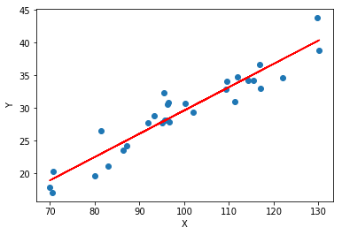

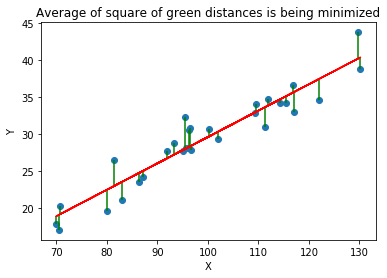

S/H

```python
from sklearn.linear_model import LinearRegression
X = np.reshape(dfxs.X.values,(-1,1))
Y = dfxs.Y.values
reg = LinearRegression().fit(X,Y)
m = reg.coef_[0]
c = reg.intercept_
print('m = ', m)
print('c = ', c)
plt.scatter(dfxs.X,dfxs.Y)
plt.plot(X,m*X+c,c='red')
#plt.vlines(x=X,ymin=m*X+c,ymax=Y,colors='green')

plt.xlabel('X')
plt.ylabel('Y')

plt.show()
plt.scatter(dfxs.X,dfxs.Y)
plt.plot(X,m*X+c,c='red')
plt.vlines(x=X,ymin=m*X+c,ymax=Y,colors='green')
plt.title('Average of square of green distances is being minimized')
plt.xlabel('X')
plt.ylabel('Y')
plt.show()
Toggle.hide_toggle()
```

### How good is our Linear Regression fit ?

1. **Mean Square Error** (MSE = $\frac{1}{N} \sum_{i=1}^{N} (\hat{y}_i-y_i)^2$) : Lower the MSE better is the fit.  
*Interesting Result: If we have minimized mean square error then sum of residuals is zero i.e. $\sum_{i=1}^{N} (\hat{y}_i-y_i) = 0$*  
2. **Coefficient of Determination (R<sup>2</sup> or r<sup>2</sup>**) :  
Is defined as proportion of the variance in the dependent variable that is predictable from the independent variables.  
Total sum of squares = SS<sub>tot</sub> = $\sum_{i=1}^{N} (y_i - \bar{y})^2$ : Proportional to the variance of data  
Sum of squares of residuals = SS<sub>res</sub> = $\sum_{i=1}^{N} (y_i - \hat{y}_i)^2$ : Proportional to the mean square error  
$R^2 \equiv 1 - \frac{SS_{res}}{SS_{tot}}$  
In the best case, the modeled values exactly match the observed values, which results in SS<sub>res</sub> = 0 and R<sup>2</sup> = 1.  
A baseline model which always predicts $\bar{y}$ will have R<sup>2</sup> = 0.  
Models that have worse predictions than this baseline will have a negative R<sup>2</sup>.

#### How good is fit of above model ?

```python
from sklearn.metrics import mean_squared_error
R2 = np.round(reg.score(X,Y),4)
MSE = np.round(mean_squared_error(m*X+c,Y),4)
SSres = np.round(30*mean_squared_error(m*X+c,Y),4)
SStot = np.round(sum((Y-np.mean(Y))**2),4)
print('R square : ',R2)
print('MSE : ',MSE,end="\n\n")
print('SS res : ',SSres)
print('SS tot: ',SStot,end="\n\n")
print('SS res / SS tot : ',np.round(SSres/SStot,4))
print('1 - (SS res / SS tot) : ',1 - np.round(SSres/SStot,4))
Toggle.hide_toggle()
```

```
R square :  0.8991
MSE :  3.7968

SS res :  113.9054
SS tot:  1129.112

SS res / SS tot :  0.1009
1 - (SS res / SS tot) :  0.8991
```

S/H

### Multiple Linear Regression

#### Uses several explanatory variables to predict the outcome of a response (or dependent) variable

#### Mathematically:

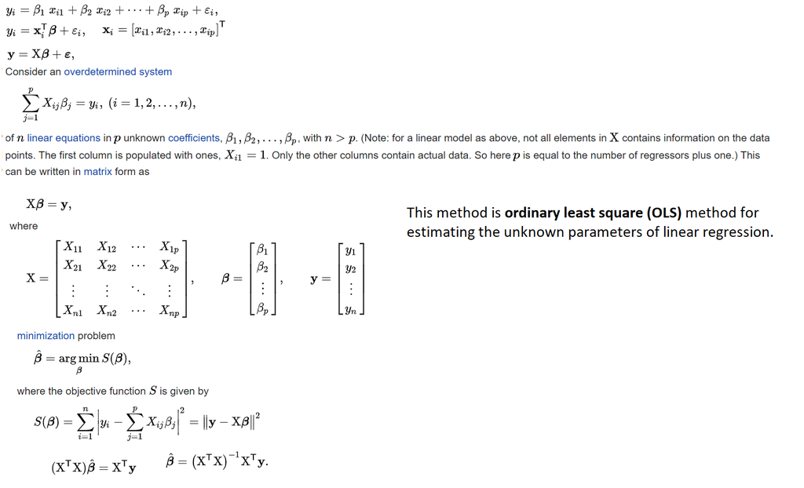

## Polynomial Regression

In many settings, linear relationship between dependent and independent variable may not hold.  
We can change the behaviour or curve of our hypothesis function by making it quadratic, cubic or square root function (or any other form)  
For example: In general, we can model the expected value of y as an nth degree polynomial, yielding the general polynomial regression model:

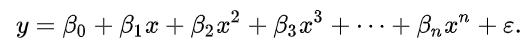

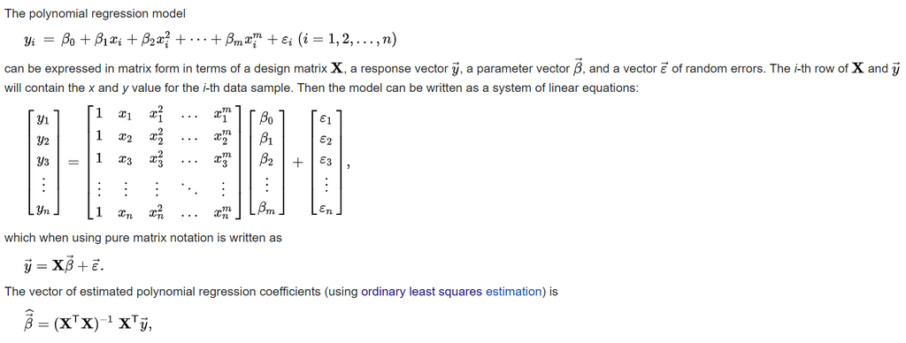